# Bike Rideshare Project

8/8/2021

The data downloaded from kaggle website from this [link](https://www.kaggle.com/datasets/mdmasumomarjashim/divvy-trips-data-20192020). The bike rideshare company believe that increasing the number of loyal customer is important for the company growth. The purpose o this analysis is explore how causal riders use the bikes differently from loyal (subscriber) riders. Ultimately, the results of the data analysis will be used to help design a plan that encourages causal rider to become subscribers.

```r
library(dplyr)
```

```r
library(tidyr)
library(ggplot2)
library(lubridate)
```

##Loading and isecting datasets

```r
Q2_2019 <- read.csv("Divvy_Trips_2019_Q2.csv",as.is=T)
Q3_2019 <- read.csv("Divvy_Trips_2019_Q3.csv",as.is=T)
Q4_2019 <- read.csv("Divvy_Trips_2019_Q4.csv",as.is=T)
Q1_2020 <- read.csv("Divvy_Trips_2020_Q1.csv",as.is=T)
```

There are discrepancies in column names and data type of some columns among the four datasets. Column names and data strucure of Divvy_Trips_2020_Q1 and will be adopted and applied to datasets.

## Data cleaning

### Renaming some columns in datsets from 2019

```r
Q2_2019_new_col_names<- rename(Q2_2019,
                               ride_id = X01...Rental.Details.Rental.ID,
                               rideable_type = X01...Rental.Details.Bike.ID,
                               started_at = X01...Rental.Details.Local.Start.Time,
                               ended_at = X01...Rental.Details.Local.End.Time,
                               start_station_name = X03...Rental.Start.Station.Name,
                               start_station_id = X03...Rental.Start.Station.ID,
                               end_station_name = X02...Rental.End.Station.Name,
                               end_station_id = X02...Rental.End.Station.ID,
                               member_casual = User.Type)

Q3_2019_new_col_names <- rename(Q3_2019,
                                ride_id = trip_id,
                                rideable_type = bikeid,
                                started_at = start_time,
                                ended_at = end_time ,
                                start_station_name = from_station_name ,
                                start_station_id = from_station_id ,
                                end_station_name = to_station_name ,
                                end_station_id = to_station_id ,
                                member_casual = usertype)


Q4_2019_new_col_names <- rename(Q4_2019,
                                ride_id = trip_id,
                                rideable_type = bikeid,
                                started_at = start_time,
                                ended_at = end_time ,
                                start_station_name = from_station_name ,
                                start_station_id = from_station_id ,
                                end_station_name = to_station_name ,
                                end_station_id = to_station_id ,
                                member_casual = usertype)
```

```r
glimpse(Q2_2019_new_col_names)
```

```
## Rows: 1,108,163
## Columns: 12
## $ ride_id                                           <int> 22178529, 22178530, …
## $ started_at                                        <chr> "2019-04-01 00:02:22…
## $ ended_at                                          <chr> "2019-04-01 00:09:48…
## $ rideable_type                                     <int> 6251, 6226, 5649, 41…
## $ X01...Rental.Details.Duration.In.Seconds.Uncapped <chr> "446.0", "1,048.0", …
## $ start_station_id                                  <int> 81, 317, 283, 26, 20…
## $ start_station_name                                <chr> "Daley Center Plaza"…
## $ end_station_id                                    <int> 56, 59, 174, 133, 12…
## $ end_station_name                                  <chr> "Desplaines St & Kin…
## $ member_casual                                     <chr> "Subscriber", "Subsc…
## $ Member.Gender                                     <chr> "Male", "Female", "M…
## $ X05...Member.Details.Member.Birthday.Year         <int> 1975, 1984, 1990, 19…
```

```r
glimpse(Q3_2019_new_col_names)
```

```
## Rows: 1,640,718
## Columns: 12
## $ ride_id            <int> 23479388, 23479389, 23479390, 23479391, 23479392, 2…
## $ started_at         <chr> "2019-07-01 00:00:27", "2019-07-01 00:01:16", "2019…
## $ ended_at           <chr> "2019-07-01 00:20:41", "2019-07-01 00:18:44", "2019…
## $ rideable_type      <int> 3591, 5353, 6180, 5540, 6014, 4941, 3770, 5442, 295…
## $ tripduration       <chr> "1,214.0", "1,048.0", "1,554.0", "1,503.0", "1,213.…
## $ start_station_id   <int> 117, 381, 313, 313, 168, 300, 168, 313, 43, 43, 511…
## $ start_station_name <chr> "Wilton Ave & Belmont Ave", "Western Ave & Monroe S…
## $ end_station_id     <int> 497, 203, 144, 144, 62, 232, 62, 144, 195, 195, 84,…
## $ end_station_name   <chr> "Kimball Ave & Belmont Ave", "Western Ave & 21st St…
## $ member_casual      <chr> "Subscriber", "Customer", "Customer", "Customer", "…
## $ gender             <chr> "Male", "", "", "", "", "Male", "", "", "", "", "",…
## $ birthyear          <int> 1992, NA, NA, NA, NA, 1990, NA, NA, NA, NA, NA, NA,…
```

```r
glimpse(Q4_2019_new_col_names)
```

```
## Rows: 704,054
## Columns: 12
## $ ride_id            <int> 25223640, 25223641, 25223642, 25223643, 25223644, 2…
## $ started_at         <chr> "2019-10-01 00:01:39", "2019-10-01 00:02:16", "2019…
## $ ended_at           <chr> "2019-10-01 00:17:20", "2019-10-01 00:06:34", "2019…
## $ rideable_type      <int> 2215, 6328, 3003, 3275, 5294, 1891, 1061, 1274, 601…
## $ tripduration       <chr> "940.0", "258.0", "850.0", "2,350.0", "1,867.0", "3…
## $ start_station_id   <int> 20, 19, 84, 313, 210, 156, 84, 156, 156, 336, 77, 1…
## $ start_station_name <chr> "Sheffield Ave & Kingsbury St", "Throop (Loomis) St…
## $ end_station_id     <int> 309, 241, 199, 290, 382, 226, 142, 463, 463, 336, 5…
## $ end_station_name   <chr> "Leavitt St & Armitage Ave", "Morgan St & Polk St",…
## $ member_casual      <chr> "Subscriber", "Subscriber", "Subscriber", "Subscrib…
## $ gender             <chr> "Male", "Male", "Female", "Male", "Male", "Female",…
## $ birthyear          <int> 1987, 1998, 1991, 1990, 1987, 1994, 1991, 1995, 199…
```

```r
glimpse(Q1_2020)
```

```
## Rows: 426,887
## Columns: 13
## $ ride_id            <chr> "EACB19130B0CDA4A", "8FED874C809DC021", "789F3C21E4…
## $ rideable_type      <chr> "docked_bike", "docked_bike", "docked_bike", "docke…
## $ started_at         <chr> "2020-01-21 20:06:59", "2020-01-30 14:22:39", "2020…
## $ ended_at           <chr> "2020-01-21 20:14:30", "2020-01-30 14:26:22", "2020…
## $ start_station_name <chr> "Western Ave & Leland Ave", "Clark St & Montrose Av…
## $ start_station_id   <int> 239, 234, 296, 51, 66, 212, 96, 96, 212, 38, 117, 1…
## $ end_station_name   <chr> "Clark St & Leland Ave", "Southport Ave & Irving Pa…
## $ end_station_id     <int> 326, 318, 117, 24, 212, 96, 212, 212, 96, 100, 632,…
## $ start_lat          <dbl> 41.9665, 41.9616, 41.9401, 41.8846, 41.8856, 41.889…
## $ start_lng          <dbl> -87.6884, -87.6660, -87.6455, -87.6319, -87.6418, -…
## $ end_lat            <dbl> 41.9671, 41.9542, 41.9402, 41.8918, 41.8899, 41.884…
## $ end_lng            <dbl> -87.6674, -87.6644, -87.6530, -87.6206, -87.6343, -…
## $ member_casual      <chr> "member", "member", "member", "member", "member", "…
```

### selecting the rquired columns from each dataset

```r
Q1_2020_v01 <- Q1_2020 %>%
  select(c("ride_id","started_at","ended_at","rideable_type",
           "start_station_id","start_station_name","end_station_id","end_station_name","member_casual"))

Q2_2019_v01 <- Q2_2019_new_col_names %>%
  select(c("ride_id","started_at","ended_at","rideable_type",
           "start_station_id","start_station_name","end_station_id","end_station_name","member_casual"))

Q3_2019_v01 <- Q3_2019_new_col_names %>%
  select(c("ride_id","started_at","ended_at","rideable_type",
           "start_station_id","start_station_name","end_station_id","end_station_name","member_casual"))

Q4_2019_v01 <- Q4_2019_new_col_names %>%
  select(c("ride_id","started_at","ended_at","rideable_type",
           "start_station_id","start_station_name","end_station_id","end_station_name","member_casual"))
```

Now, all columns needed for the analysis from all datasets have identical names. However, “trip_id” and “rideable_type” in 2019 datasets need to be converted to “character datatype to match 2020 dataset.

```r
Q2_2019_v02 <- mutate(Q2_2019_v01, ride_id = as.character(ride_id),
                                rideable_type = as.character(rideable_type))

Q3_2019_v02 <- mutate(Q3_2019_v01, ride_id = as.character(ride_id),
                                rideable_type = as.character(rideable_type))
Q4_2019_v02 <- mutate(Q4_2019_v01, ride_id = as.character(ride_id),
                                rideable_type = as.character(rideable_type))


Q1_2020_v02<-Q1_2020_v01
```

### Combining all datasets

```r
data_v01 <- bind_rows(Q2_2019_v02, Q3_2019_v02, Q4_2019_v02, Q1_2020_v02)

glimpse(data_v01)
```

```
## Rows: 3,879,822
## Columns: 9
## $ ride_id            <chr> "22178529", "22178530", "22178531", "22178532", "22…
## $ started_at         <chr> "2019-04-01 00:02:22", "2019-04-01 00:03:02", "2019…
## $ ended_at           <chr> "2019-04-01 00:09:48", "2019-04-01 00:20:30", "2019…
## $ rideable_type      <chr> "6251", "6226", "5649", "4151", "3270", "3123", "64…
## $ start_station_id   <int> 81, 317, 283, 26, 202, 420, 503, 260, 211, 211, 304…
## $ start_station_name <chr> "Daley Center Plaza", "Wood St & Taylor St", "LaSal…
## $ end_station_id     <int> 56, 59, 174, 133, 129, 426, 500, 499, 211, 211, 232…
## $ end_station_name   <chr> "Desplaines St & Kinzie St", "Wabash Ave & Roosevel…
## $ member_casual      <chr> "Subscriber", "Subscriber", "Subscriber", "Subscrib…
```

### Checking for duplicates

```r
length(unique(data_v01$ride_id)) == nrow(data_v01)
```

```
## [1] TRUE
```

Return TRUE means no duplicate

### Checking for missing values in the dataset

```r
apply(is.na(data_v01), 2, which)
```

```
## $ride_id
## integer(0)
##
## $started_at
## integer(0)
##
## $ended_at
## integer(0)
##
## $rideable_type
## integer(0)
##
## $start_station_id
## integer(0)
##
## $start_station_name
## integer(0)
##
## $end_station_id
## [1] 3867362
##
## $end_station_name
## integer(0)
##
## $member_casual
## integer(0)
```

### Creating a new column to calculate trips duration in seconds.

```r
data_v02 <- data_v01 %>%
  mutate(ride_duration=difftime(ended_at,started_at, units = "secs"))
```

Inspecting first rows of the dataset

```r
head(data_v02)
```

```
##    ride_id          started_at            ended_at rideable_type
## 1 22178529 2019-04-01 00:02:22 2019-04-01 00:09:48          6251
## 2 22178530 2019-04-01 00:03:02 2019-04-01 00:20:30          6226
## 3 22178531 2019-04-01 00:11:07 2019-04-01 00:15:19          5649
## 4 22178532 2019-04-01 00:13:01 2019-04-01 00:18:58          4151
## 5 22178533 2019-04-01 00:19:26 2019-04-01 00:36:13          3270
## 6 22178534 2019-04-01 00:19:39 2019-04-01 00:23:56          3123
##   start_station_id        start_station_name end_station_id
## 1               81        Daley Center Plaza             56
## 2              317       Wood St & Taylor St             59
## 3              283 LaSalle St & Jackson Blvd            174
## 4               26  McClurg Ct & Illinois St            133
## 5              202      Halsted St & 18th St            129
## 6              420       Ellis Ave & 55th St            426
##            end_station_name member_casual ride_duration
## 1 Desplaines St & Kinzie St    Subscriber      446 secs
## 2 Wabash Ave & Roosevelt Rd    Subscriber     1048 secs
## 3     Canal St & Madison St    Subscriber      252 secs
## 4  Kingsbury St & Kinzie St    Subscriber      357 secs
## 5 Blue Island Ave & 18th St    Subscriber     1007 secs
## 6       Ellis Ave & 60th St    Subscriber      257 secs
```

```r
min(data_v02$ride_duration)
```

```
## Time difference of -6982 secs
```

There are some non valid time value less than 0. These will dropped

```r
data_v03 <- data_v02 %>%filter(ride_duration> 0)

min(data_v03$ride_duration)
```

```
## Time difference of 1 secs
```

### Adding new columns for trips starting time in hours, days of the week and months

```r
data_v04 <- data_v03 %>%
  mutate(hour= hour(started_at)) %>%
  mutate(days= wday(started_at,lab= T,abbr = F))  %>%
  mutate(month= month(started_at, lab= T,abbr = F))%>%
  mutate(year= year(started_at))
```

```r
glimpse(data_v04)
```

```
## Rows: 3,879,599
## Columns: 14
## $ ride_id            <chr> "22178529", "22178530", "22178531", "22178532", "22…
## $ started_at         <chr> "2019-04-01 00:02:22", "2019-04-01 00:03:02", "2019…
## $ ended_at           <chr> "2019-04-01 00:09:48", "2019-04-01 00:20:30", "2019…
## $ rideable_type      <chr> "6251", "6226", "5649", "4151", "3270", "3123", "64…
## $ start_station_id   <int> 81, 317, 283, 26, 202, 420, 503, 260, 211, 211, 304…
## $ start_station_name <chr> "Daley Center Plaza", "Wood St & Taylor St", "LaSal…
## $ end_station_id     <int> 56, 59, 174, 133, 129, 426, 500, 499, 211, 211, 232…
## $ end_station_name   <chr> "Desplaines St & Kinzie St", "Wabash Ave & Roosevel…
## $ member_casual      <chr> "Subscriber", "Subscriber", "Subscriber", "Subscrib…
## $ ride_duration      <drtn> 446 secs, 1048 secs, 252 secs, 357 secs, 1007 secs…
## $ hour               <int> 0, 0, 0, 0, 0, 0, 0, 0, 0, 0, 0, 0, 1, 1, 1, 1, 1, …
## $ days               <ord> Monday, Monday, Monday, Monday, Monday, Monday, Mon…
## $ month              <ord> April, April, April, April, April, April, April, Ap…
## $ year               <dbl> 2019, 2019, 2019, 2019, 2019, 2019, 2019, 2019, 201…
```

Finally, “member_casual” categorical variable defined differently in 2019 datasets (Subscriber/ Customer ) from 2020 dataset (member/casual).

```r
ride_count <- data_v04 %>%group_by(member_casual) %>%
  summarise(number_of_rides = n())

ride_count
```

```
## # A tibble: 4 × 2
##   member_casual number_of_rides
##   <chr>                   <int>
## 1 casual                  48270
## 2 Customer               857468
## 3 member                 378407
## 4 Subscriber            2595454
```

Again will use 2020 format and Subscriber/ Customer to member/casual.

```r
data_v04<- data_v04 %>% mutate(member_casual=  case_when(
  member_casual == "member" ~ "member",
  member_casual =="casual" ~ "casual",
  member_casual == "Customer" ~ "casual",  # replace customer with casual
  member_casual == "Subscriber" ~ "member"))   # replace Subscriber with member


ride_count <- data_v04 %>%group_by(member_casual) %>%
  summarise(number_of_rides = n())

ride_count
```

```
## # A tibble: 2 × 2
##   member_casual number_of_rides
##   <chr>                   <int>
## 1 casual                 905738
## 2 member                2973861
```

## Data analysis and Visulaization

### Some descriptive statistics

Average trip duration based on customer type

```r
data_v04 %>%  group_by(member_casual) %>%
  summarize(mean_ride_duration=mean(ride_duration),
            median_ride_duration=median(ride_duration),
            minimum_ride_duration=min(ride_duration),
            maximum_ride_duration=max(ride_duration))
```

```
## # A tibble: 2 × 5
##   member_casual mean_ride_duration median_ride_duration minimum_ride_d…¹ maxim…²
##   <chr>         <drtn>             <drtn>               <drtn>           <drtn>
## 1 casual        3538.859 secs      1541 secs            1 secs           938342…
## 2 member         850.078 secs       589 secs            1 secs           905663…
## # … with abbreviated variable names ¹minimum_ride_duration,
## #   ²maximum_ride_duration
```

### Calculating and plotting number of rides groupped by customer type

```r
data_count<- data_v04 %>%
  group_by(member_casual) %>%
  count() %>%
  ungroup() %>%
  mutate(percent=`n`/sum(`n`)) %>%
  arrange(desc(member_casual))

data_count
```

```
## # A tibble: 2 × 3
##   member_casual       n percent
##   <chr>           <int>   <dbl>
## 1 member        2973861   0.767
## 2 casual         905738   0.233
```

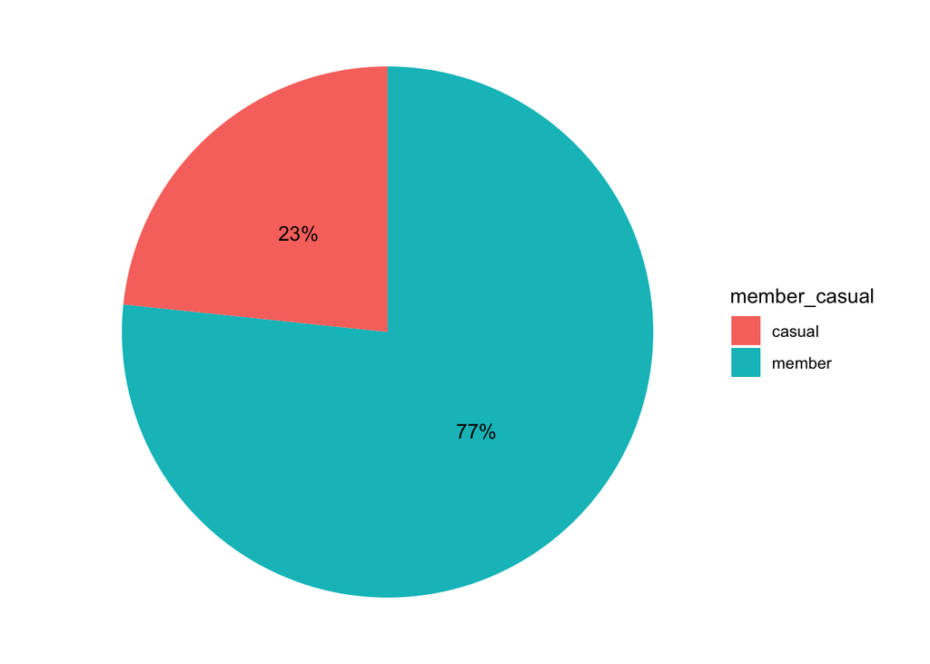

```r
data_count$label <- scales::percent(data_count$percent)
ggplot(data=data_count)+
  geom_bar(aes(x="", y=percent, fill=member_casual), stat="identity", width = 1)+
  coord_polar("y", start=0)+
  theme_void()+
  geom_text(aes(x=1, y = cumsum(percent) - percent/2, label=label))
```

The subscribers (members) represent the majority of riders.

### Number of trips grouped by starting time of the trips in hour of the day and customer type (member/casual)

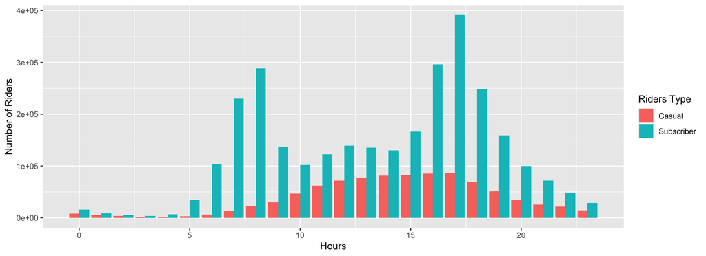

```r
data_v04 %>%
  group_by(member_casual, hour) %>%
  summarise(number_of_rides = n()) %>%
  ggplot(aes(x = hour, y = number_of_rides, fill = member_casual)) +
  geom_col(position = "dodge") + scale_fill_discrete(name = "Riders Type", labels = c("Casual", "Subscriber"))+
  xlab("Hours")+ ylab("Number of Riders")
```

### Number of trips grouped by day of the week and customer type (member/casual)

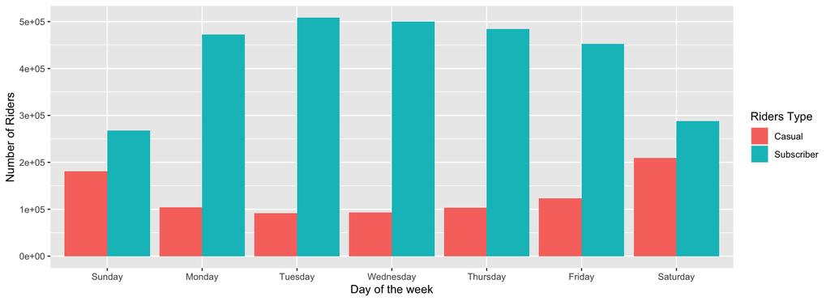

```r
data_v04 %>%
  group_by(member_casual, days) %>%
  summarise(number_of_rides = n()) %>%
  ggplot(aes(x = days, y = number_of_rides, fill = member_casual)) +
  geom_col(position = "dodge") + scale_fill_discrete (name = "Riders Type", labels = c("Casual", "Subscriber"))+
  xlab("Day of the week")+ ylab("Number of Riders")
```

### Number of trips grouped by months and customer type (member/casual)

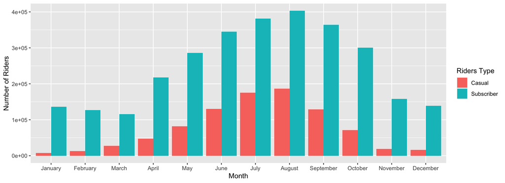

```r
data_v04 %>%
  group_by(member_casual, month) %>%
  summarise(number_of_rides = n()) %>%
  ggplot(aes(x = month, y = number_of_rides, fill = member_casual)) +
  geom_col(position = "dodge") + scale_fill_discrete (name = "Riders Type", labels = c("Casual", "Subscriber"))+
  xlab("Month")+ ylab("Number of Riders")
```

Clearly the number of rides started to increase in in spring and peaked in summer time which parallels with the improvement of weather.The majority of riders are subscribers.

### plotting average of rides duration grouped by starting time of the day and customer type (subscriber/casual)

```
## Defaulting to continuous.
```

[figure not shown]

```r
data_v04 %>%
  mutate(hour = hour) %>%
  group_by(member_casual, hour) %>%
  summarise(average_duration = mean(ride_duration)) %>%
  ggplot(aes(x = hour, y = average_duration, fill = member_casual)) +
  geom_col(position = "dodge") + scale_fill_discrete(name = "Riders Type", labels = c("Casual", "Subscriber"))+
  xlab("Hours")+ ylab("Average Ride Duration in hours")
```

Above figure shows that causal riders tend to ride longer time compared to subscribers throughout the day.

### Plotting average of rides duration grouped by the weekdays and customer type (member/casual)

```
## Defaulting to continuous.
```

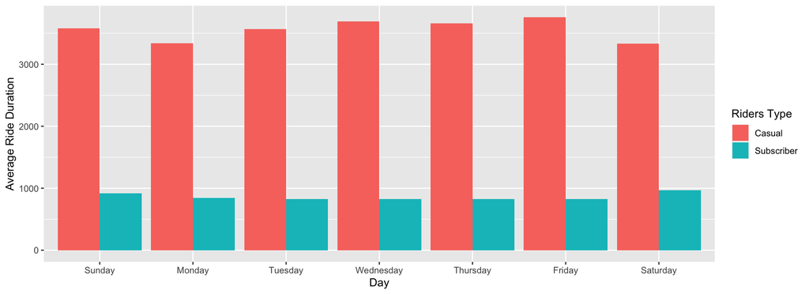

```r
data_v04 %>%
  mutate(weekdays = days) %>%
  group_by(member_casual, weekdays) %>%
  summarise(average_duration = mean(ride_duration)) %>%
  ggplot(aes(x = weekdays, y = average_duration, fill = member_casual)) +
  geom_col(position = "dodge") + scale_fill_discrete (name = "Riders Type", labels = c("Casual", "Subscriber"))+
  xlab("Day")+ ylab("Average Ride Duration")
```

There is no pattern can be seen in average rides duration based on the day of the week.

### Plotting average of rides duration grouped months and customer type (member/casual)

```
## Defaulting to continuous.
```

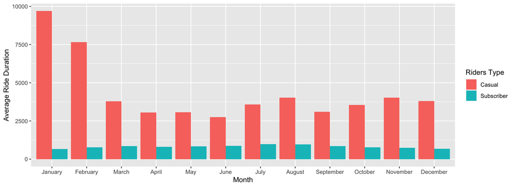

```r
data_v04 %>%
  group_by(member_casual, month) %>%
  summarise(average_duration = mean(ride_duration)) %>%
  ggplot(aes(x = month, y = average_duration, fill = member_casual)) +
  geom_col(position = "dodge") + scale_fill_discrete (name = "Riders Type", labels = c("Casual", "Subscriber"))+
  xlab("Month")+ ylab("Average Ride Duration")
```